# DPP Survey 2022 Data

# Replying

The next few questions have to do with replying to posts. Once again the biggest question, *did* our users actually reply to posts in 2022?

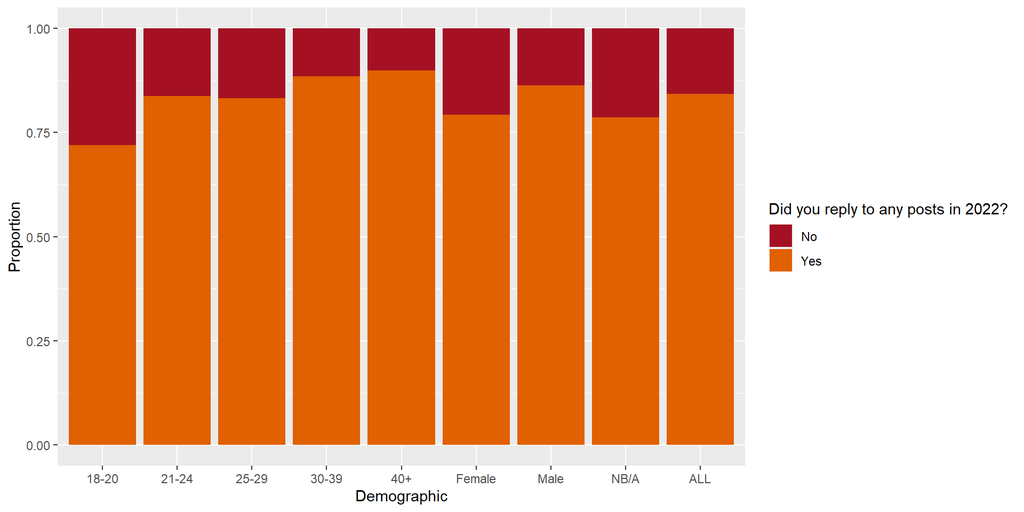

Were they replying to posters of the same gender or another gender?

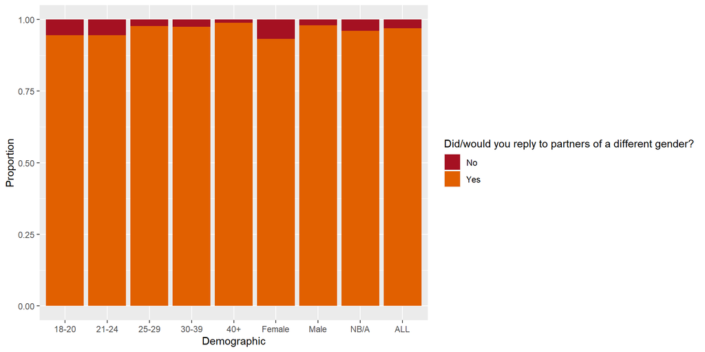

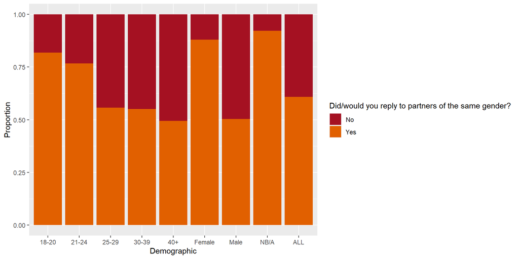

And were they replying to posts seeking conversation or roleplay?

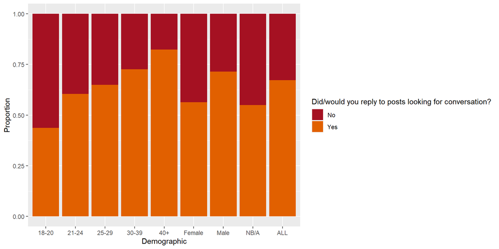

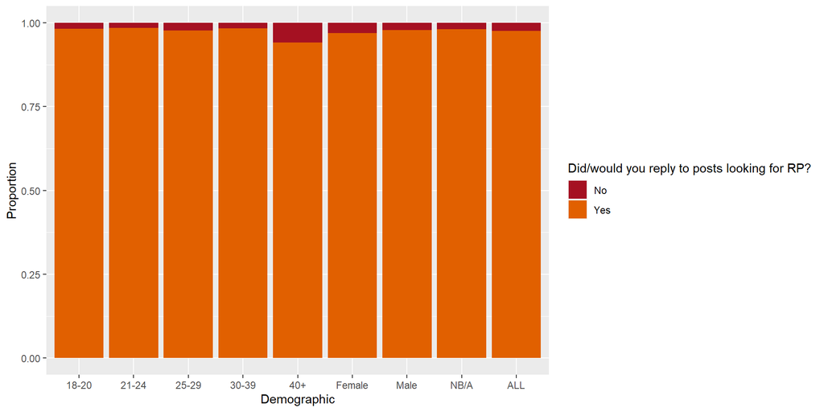

How often did those replies pan out?

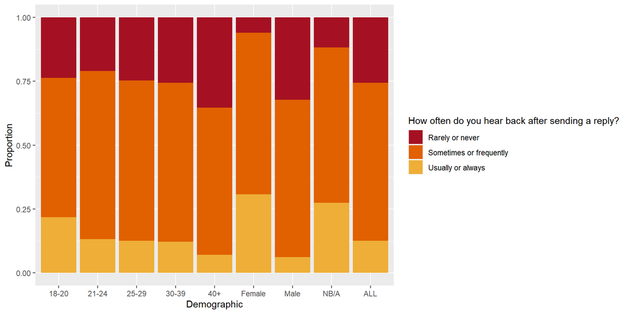

And how often did they result in the proverbial happy ending?

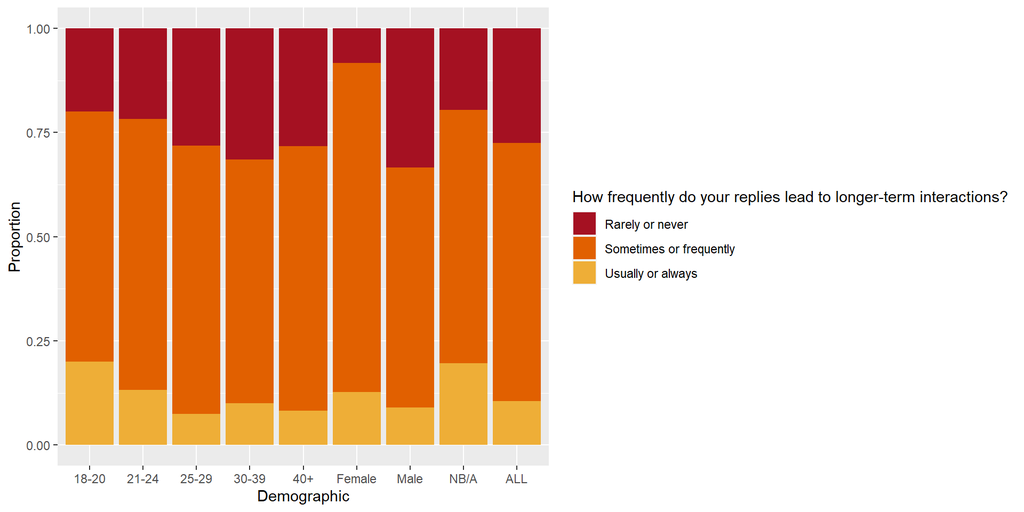

And finally, would they reply to a post that used novelty tags?

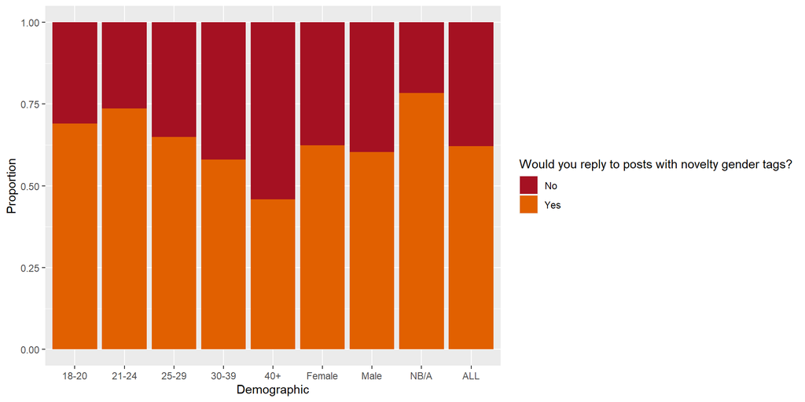

# Mod Action

The next questions have to do with how users interact with the moderation of DPP.

First, did they get a post removed, however it happened?

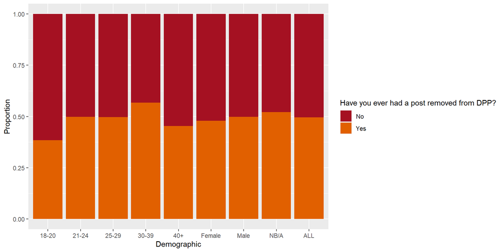

Was the removal reason useful to them? We’re always seeking to improve them, but they’re not perfect.

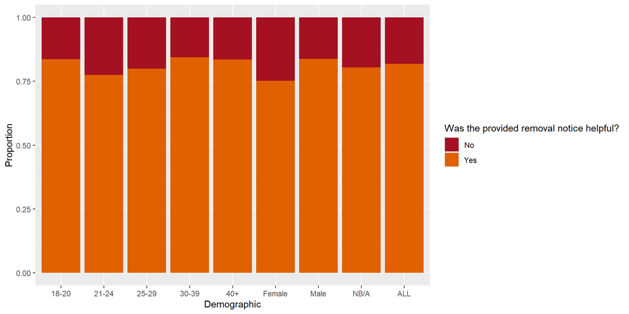

Did they engage with the mod team and ask to have their post restored after edits? In a perfect world this would be 100%.

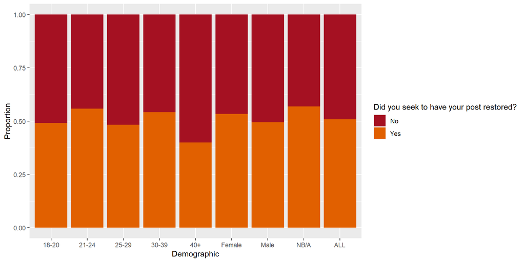

And, well, did it work?

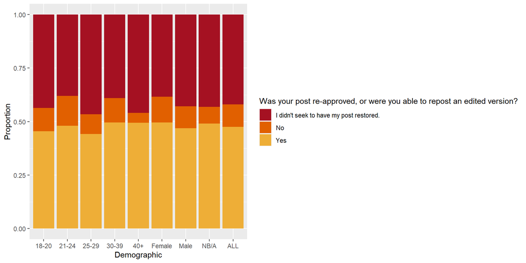

#Contact Methods

The next questions all have to do with methods of correspondence on DPP.

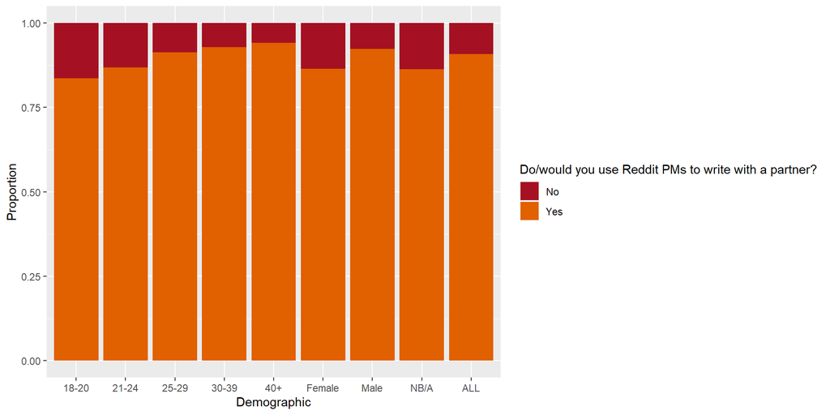

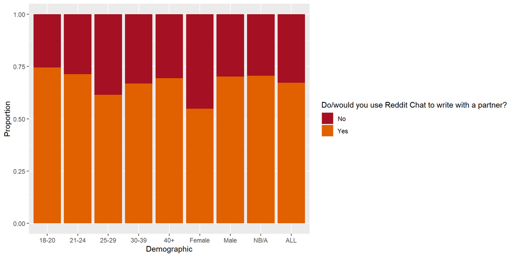

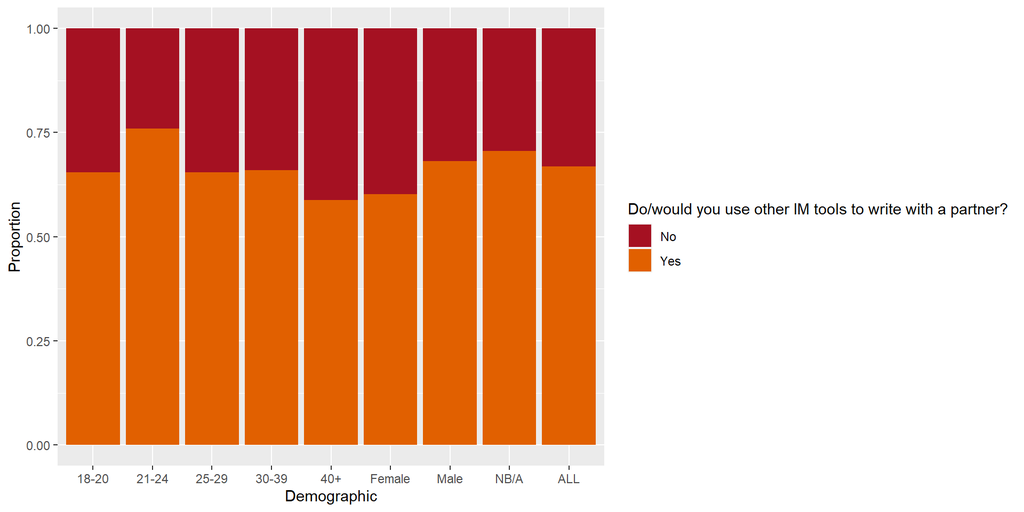

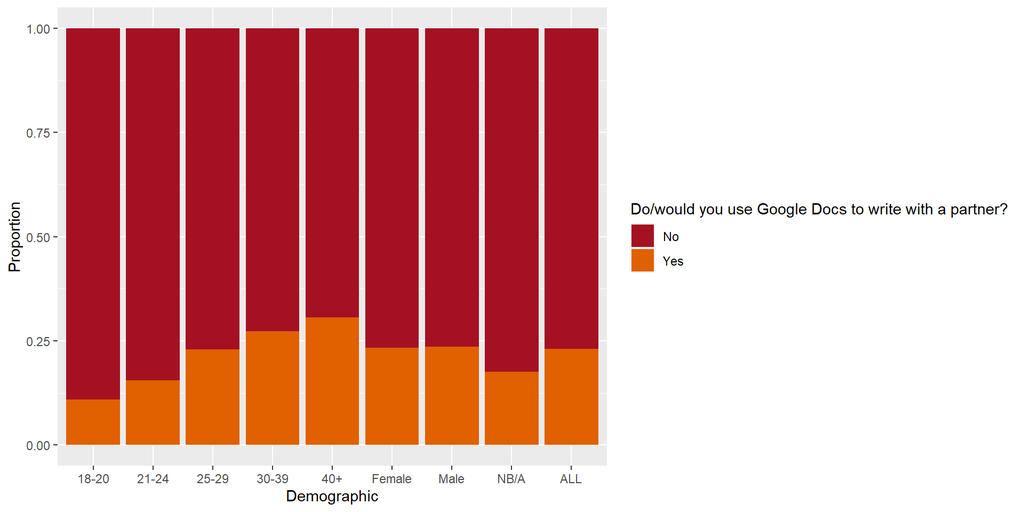

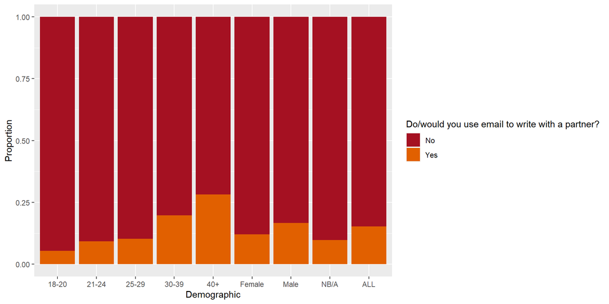

# Factors Influencing Interest

These next few questions all have to do with how users evaluate other DPP users, and what factors might affect their decision to reply to a post or answer an inquiry.

First, account age and post history.

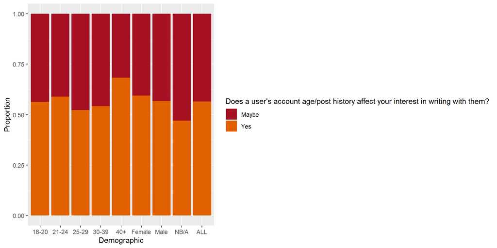

Next, accounts being new - note that this doesn’t mean new to DPP, that’s a bit later.

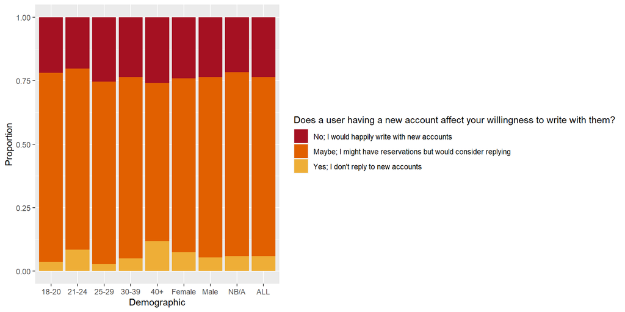

Is u/friendlyfunDPPer a more welcoming name than u/Generic_Llama777?

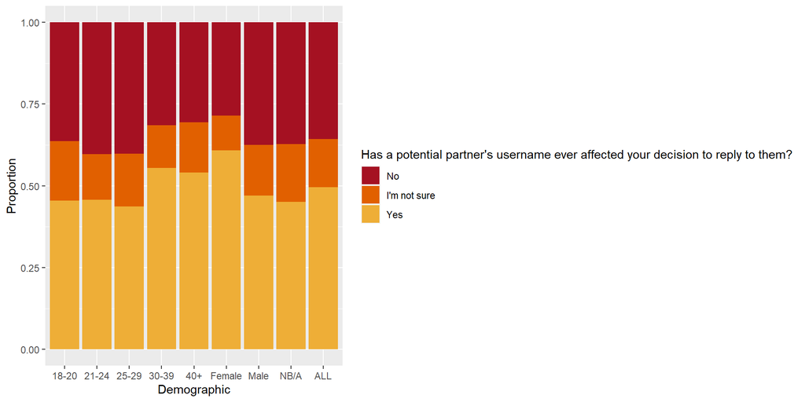

Ah, here it is. Is an absence of DPP history important to our users?

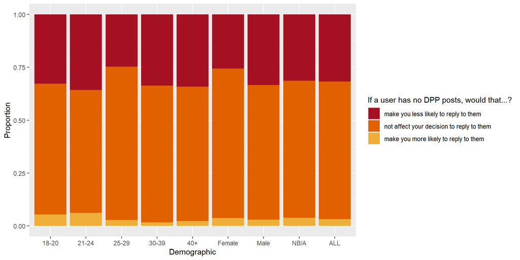

And, is a totally blank profile an issue?

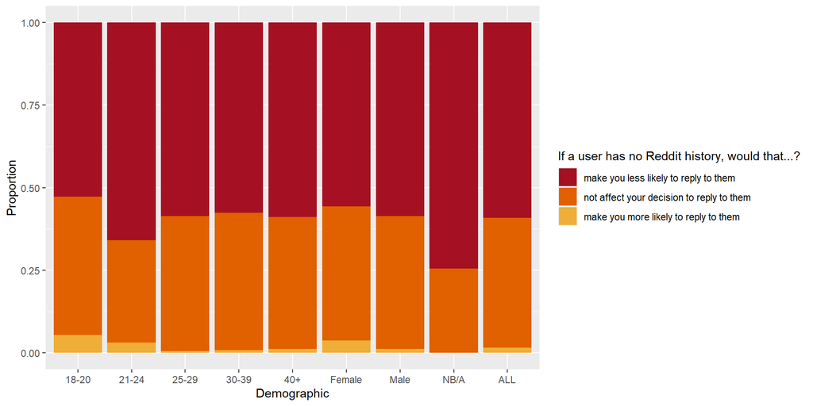

Finally, is it important for someone to have a bit of smut under their belt? Keep in mind, some folks delete many of their posts, so sometimes it’s hard to tell.

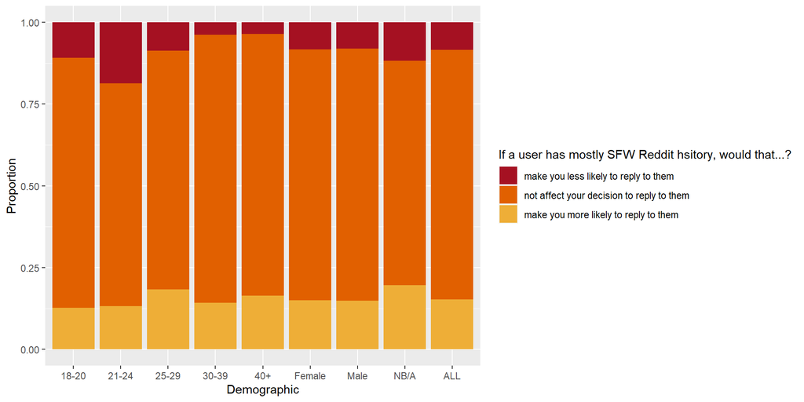

# Satisfaction

These next few questions all have to do with users’ general level of satisfaction with DPP.

First, their happiness with their interactions on the sub - covering just about everything.

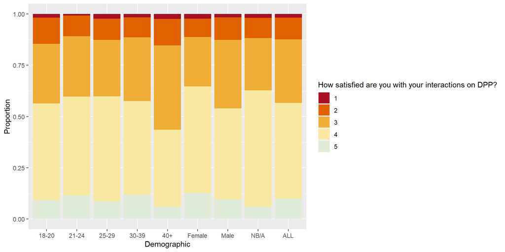

Then, their happiness with the content they see on the sub.

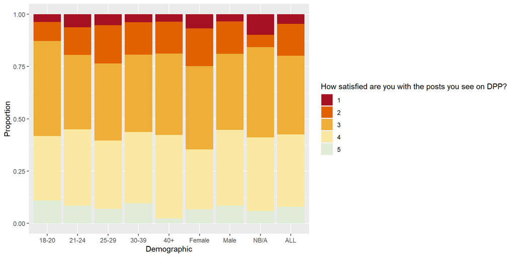

And the big one, happiness with the rules.

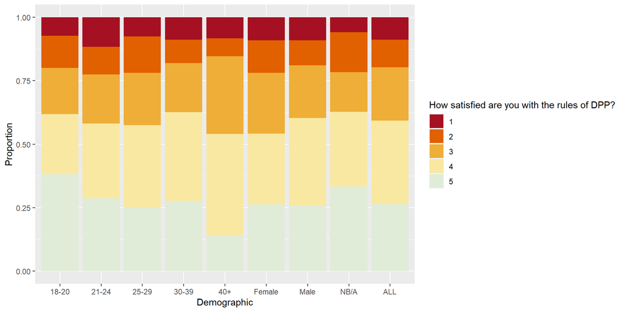

No less important, satisfaction with the events we offer each week.

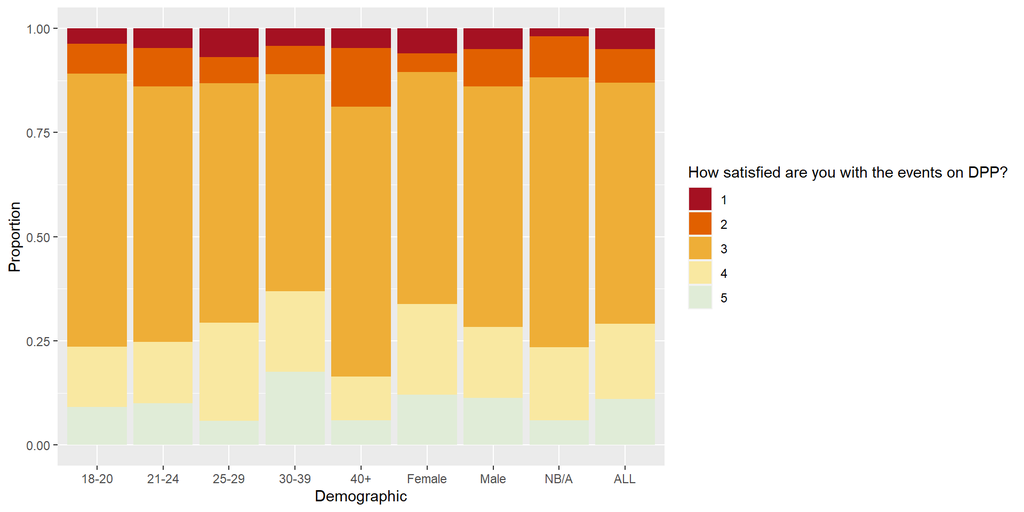

And the other big one, satisfaction with DPP moderation.

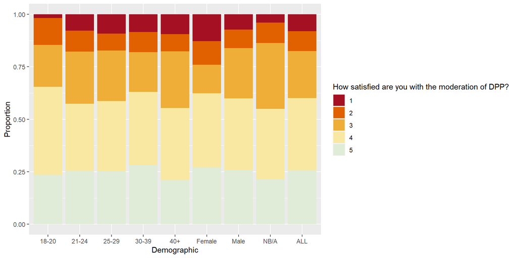

These two don’t have to do with satisfaction, but they do help us make decisions about how to communicate rules changes. Who’s read the main rules linked in the sidebar, and who’s just read the sidebar?

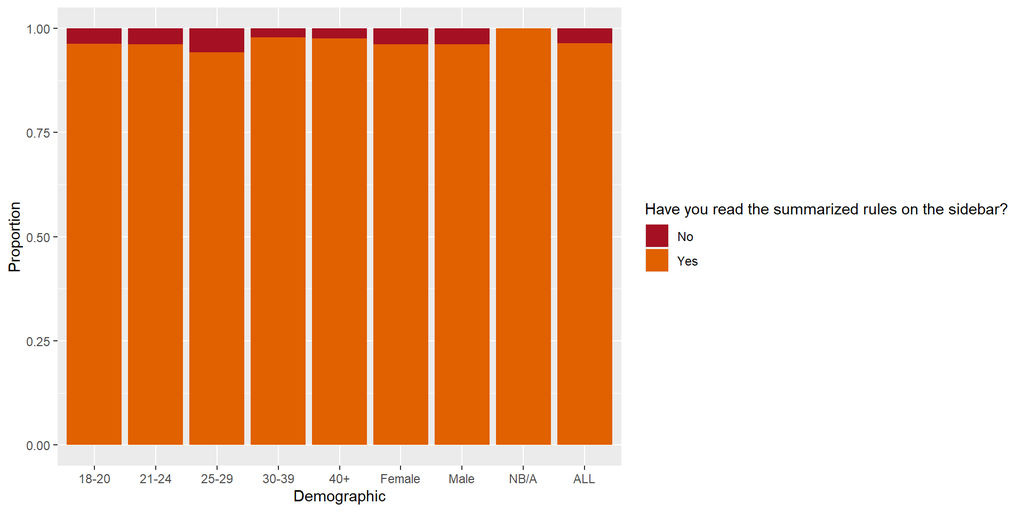

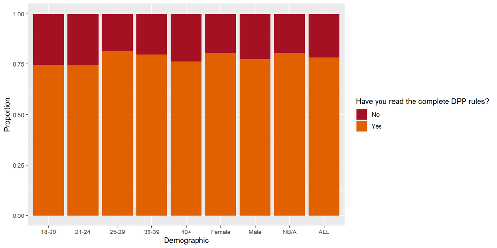

Finally, how happy are our users with the current time limit between posts, and the current three-per-week repost limit?

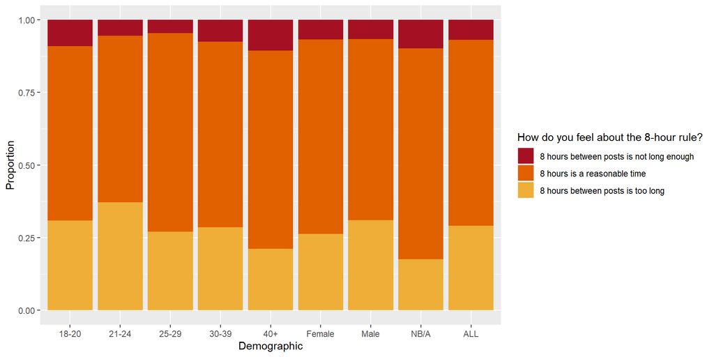

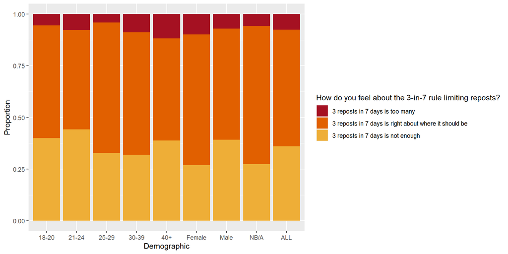